# Отчет по лабораторной работе №10

Текстовой редактор vi

Виноградова М.А

Российский университет дружбы народов, Москва, Россия

19 апреля 2025

# Информация

## Докладчик

- Виноградова Мария Андреевна
- студентка НПИбд-01-24
- номер студ. билета 1132240691
- Российский университет дружбы народов
- 1132240691@pfur.ru
- https://github.com/mavinogradova/study_2024-2025_os-intro

## Цель работы

Познакомиться с операционной системой Linux. Получить практические навыки работы с редактором vi, установленным по умолчанию практически во всех дистрибутивах

# Выполнение лабораторной работы

1. Ознакомиться с теоретическим материалом.
2. Ознакомиться с редактором vi.
3. Выполнить упражнения, используя команды vi.

## 4. Нажмите клавишу i и введите текст

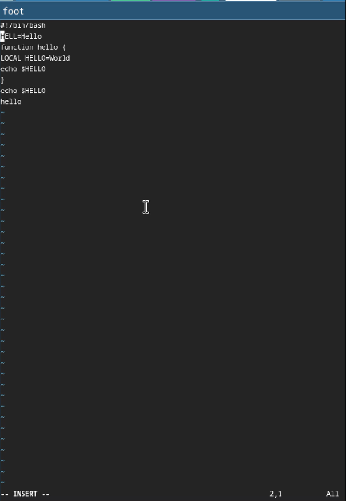

Вводим текст

## 5. Нажмите клавишу Esc для перехода в командный режим после завершения ввода текста.

## 6. Нажмите : для перехода в режим последней строки и внизу вашего экрана появится приглашение в виде двоеточия.

## 7. Нажмите w (записать) и q (выйти), а затем нажмите клавишу Enter для сохранения вашего текста и завершения работы.

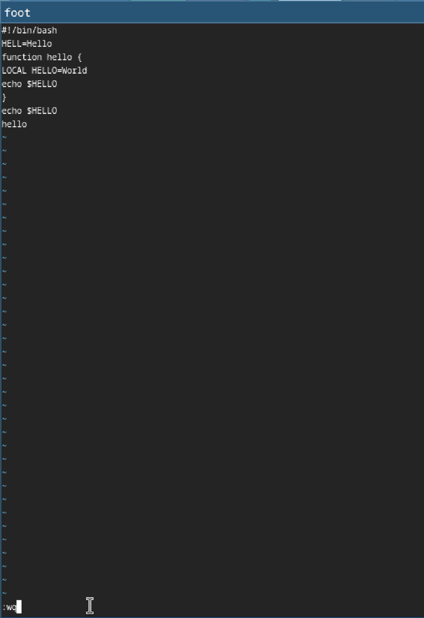

Нажимаем wq и клавишу Enter

## Задание 2. Редактирование существующего файла

## 1. Вызовите vi на редактирование файла

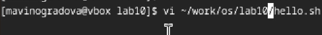

Вызываем vi

## 2. Установите курсор в конец слова HELL второй строки.

## 3. Перейдите в режим вставки и замените на HELLO. Нажмите Esc для возврата в командный режим.

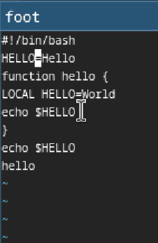

Переходим в режим вставки и заменяем

## 4. Установите курсор на четвертую строку и сотрите слово LOCAL.

## 5. Перейдите в режим вставки и наберите следующий текст: local, нажмите Esc для возврата в командный режим.

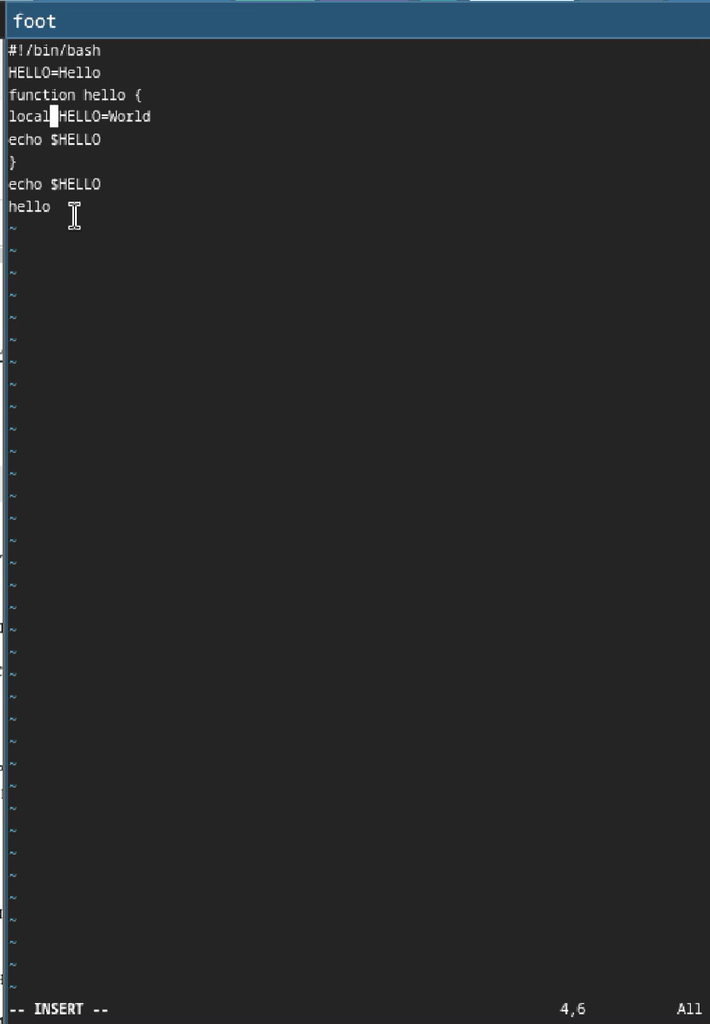

Переходим в режим вставки и набираем текст

## 6. Установите курсор на последней строке файла. Вставьте после неё строку, содержащую следующий текст: echo $HELLO.

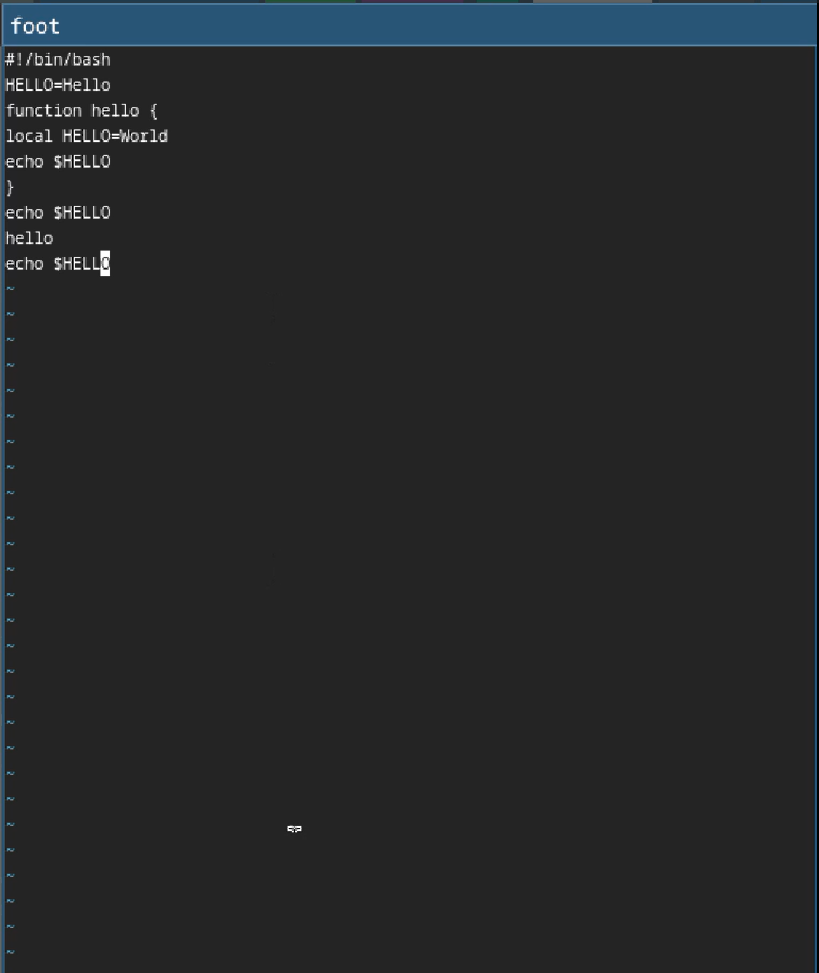

Вставляем строку

[figure not shown]

Вставляем строку

## 7. Нажмите Esc для перехода в командный режим.

## 8. Удалите последнюю строку.

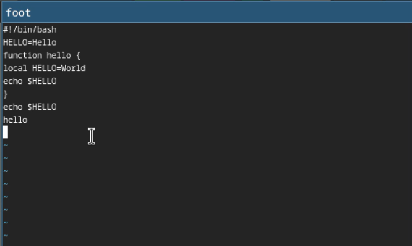

Удаляем строку

## 9. Введите команду отмены изменений u для отмены последней команды.

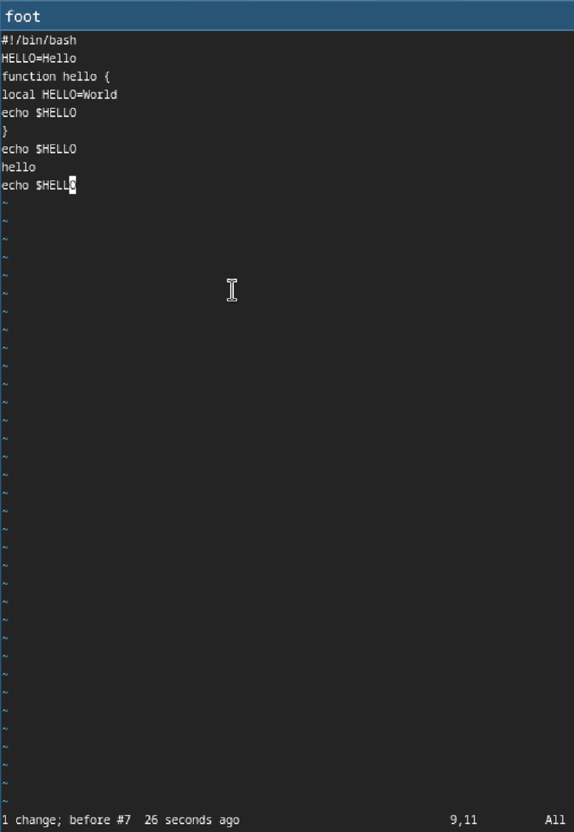

Вводим команду отмены изменений u

## 10. Введите символ : для перехода в режим последней строки. Запишите произведённые изменения и выйдите из vi

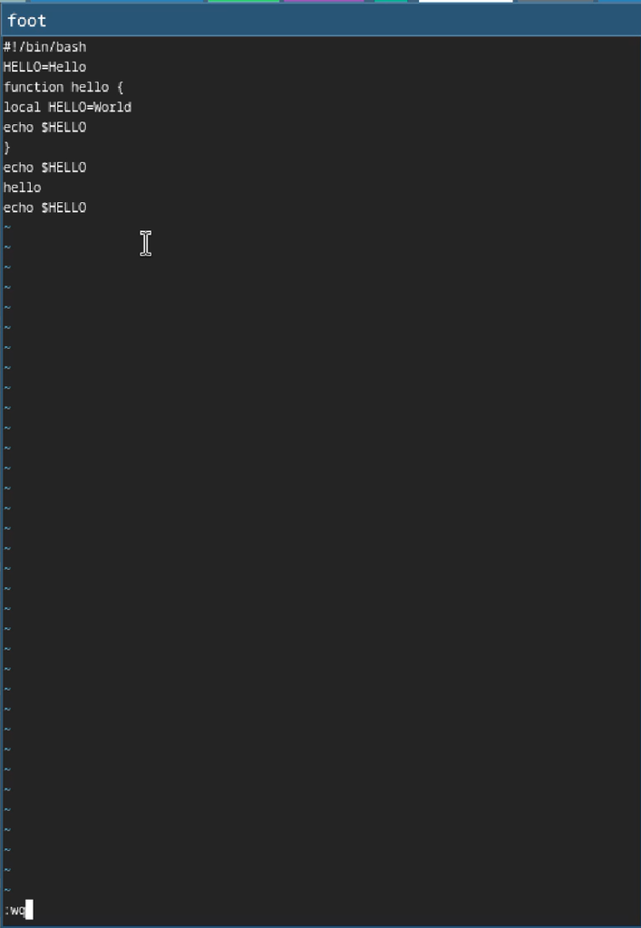

Нажимаем wq и клавишу Enter

# Выводы

В ходе работы освоены основы работы в Linux и текстовом редакторе vi. Приобретены навыки создания, редактирования и сохранения файлов, навигации по тексту и использования основных команд. Редактор vi доказал свою эффективность для работы в терминальном режиме. Полученные знания необходимы для администрирования Linux-систем.